# week_04_layers

## CMPINF 2130 Summer 2021 - Week 04

## Import modules

```python
import numpy as np
import pandas as pd
import matplotlib.pyplot as plt

import seaborn as sns
```

## Import iris

```python
import statsmodels.api as sm
```

```python
iris = sm.datasets.get_rdataset('iris').data
```

```python
iris.info()
```

```
<class 'pandas.core.frame.DataFrame'>
RangeIndex: 150 entries, 0 to 149
Data columns (total 5 columns):
 #   Column        Non-Null Count  Dtype
---  ------        --------------  -----
 0   Sepal.Length  150 non-null    float64
 1   Sepal.Width   150 non-null    float64
 2   Petal.Length  150 non-null    float64
 3   Petal.Width   150 non-null    float64
 4   Species       150 non-null    object
dtypes: float64(4), object(1)
memory usage: 6.0+ KB
```

## Scatter plot with Seaborn

If we want to make a plot or a graphic with subplots/facets associated with a variable in the data set, we **must** use the figure level functions in Seaborn.

A scatter plot is a kind of **relationship** plot in Seaborn, so the figure level function is `sns.relplot()`.

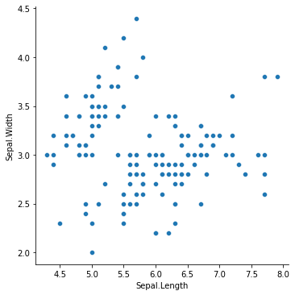

```python
sns.relplot(data = iris, x='Sepal.Length', y='Sepal.Width',
            kind = 'scatter')

plt.show()
```

We want the color to denote Petal.Length, the size to denote Petal.Width and the facet to denote Species. Seaborn allows **semantic variables** hue, shape, size (in addition to x and y).

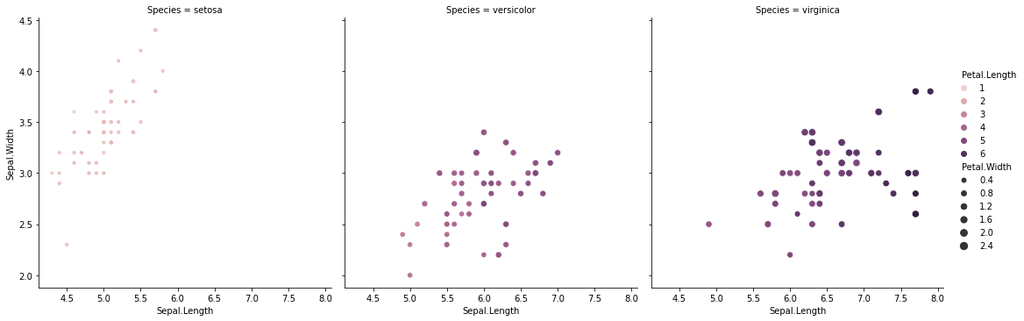

```python
sns.relplot(data = iris, x='Sepal.Length', y = 'Sepal.Width',
            hue = 'Petal.Length',
            col = 'Species',
            size = 'Petal.Width',
            kind='scatter')

plt.show()
```

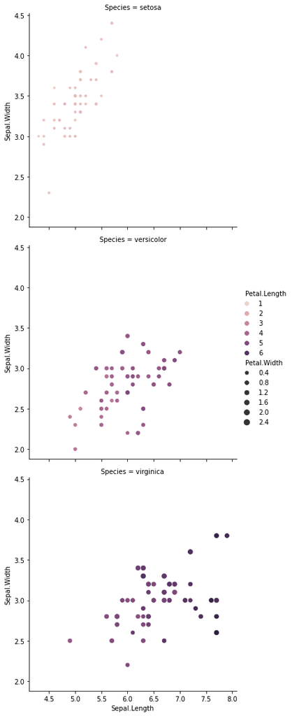

```python
sns.relplot(data = iris, x='Sepal.Length', y = 'Sepal.Width',
            hue = 'Petal.Length',
            col = 'Species',
            col_wrap=1,
            size = 'Petal.Width',
            kind='scatter')

plt.show()
```

We can modify the color **palette** in Seaborn with the `palette` argument.

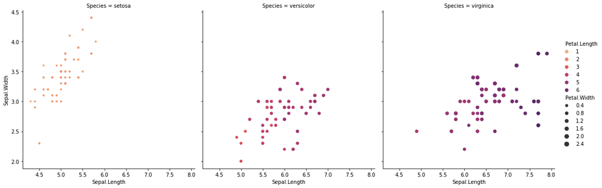

```python
sns.relplot(data = iris, x='Sepal.Length', y = 'Sepal.Width',
            hue = 'Petal.Length',
            col = 'Species',
            size = 'Petal.Width',
            palette='flare',
            kind='scatter')

plt.show()
```

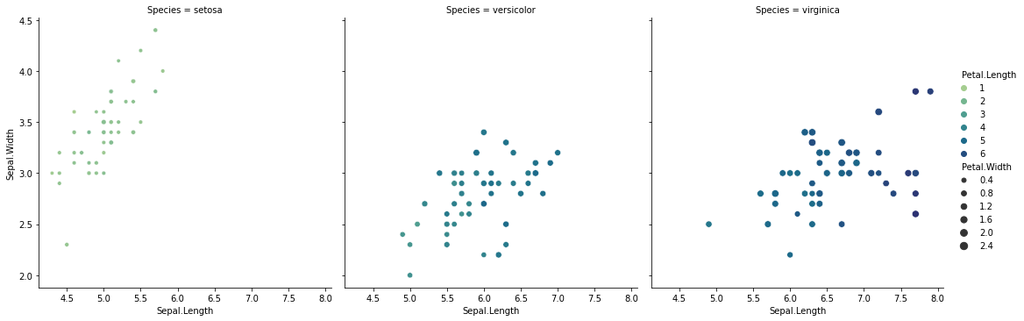

```python
sns.relplot(data = iris, x='Sepal.Length', y = 'Sepal.Width',
            hue = 'Petal.Length',
            col = 'Species',
            size = 'Petal.Width',
            palette='crest',
            kind='scatter')

plt.show()
```

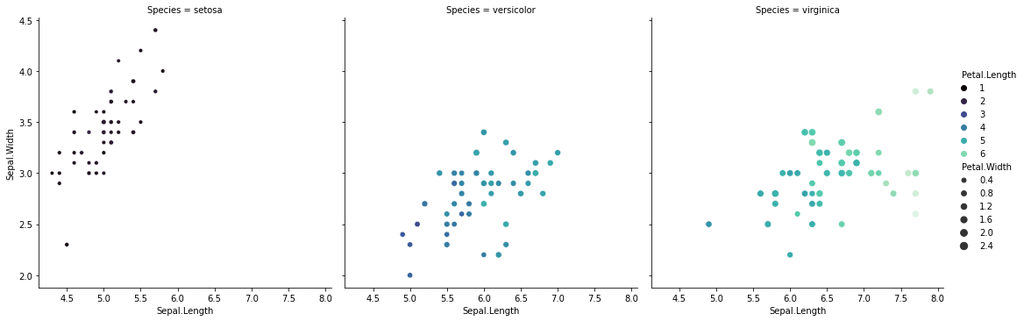

```python
sns.relplot(data = iris, x='Sepal.Length', y = 'Sepal.Width',
            hue = 'Petal.Length',
            col = 'Species',
            size = 'Petal.Width',
            palette='mako',
            kind='scatter')

plt.show()
```

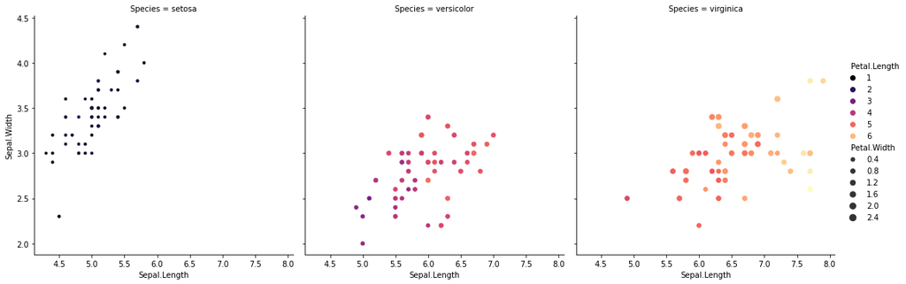

```python
sns.relplot(data = iris, x='Sepal.Length', y = 'Sepal.Width',
            hue = 'Petal.Length',
            col = 'Species',
            size = 'Petal.Width',
            palette='magma',
            kind='scatter')

plt.show()
```

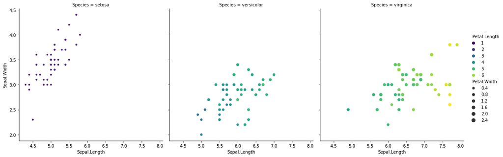

```python
sns.relplot(data = iris, x='Sepal.Length', y = 'Sepal.Width',
            hue = 'Petal.Length',
            col = 'Species',
            size = 'Petal.Width',
            palette='viridis',
            kind='scatter')

plt.show()
```

Diverging color scales.

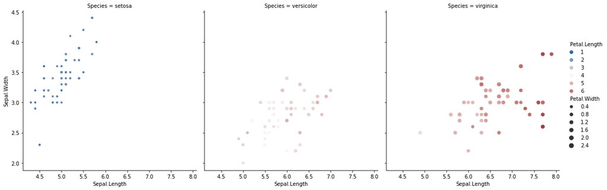

```python
sns.relplot(data = iris, x='Sepal.Length', y = 'Sepal.Width',
            hue = 'Petal.Length',
            col = 'Species',
            size = 'Petal.Width',
            palette='vlag',
            kind='scatter')

plt.show()
```

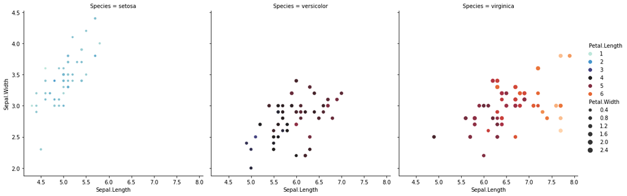

```python
sns.relplot(data = iris, x='Sepal.Length', y = 'Sepal.Width',
            hue = 'Petal.Length',
            col = 'Species',
            size = 'Petal.Width',
            palette='icefire',
            kind='scatter')

plt.show()
```

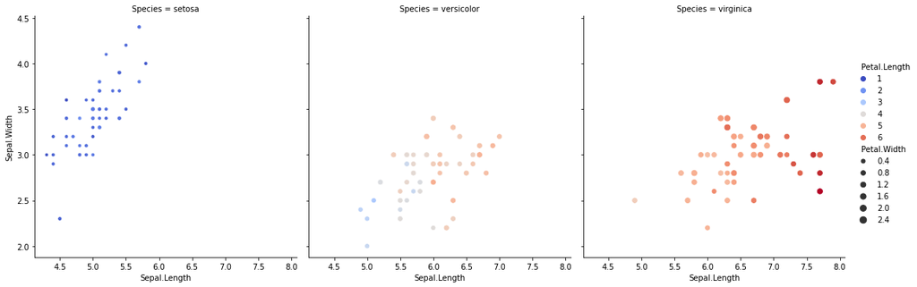

```python
sns.relplot(data = iris, x='Sepal.Length', y = 'Sepal.Width',
            hue = 'Petal.Length',
            col = 'Species',
            size = 'Petal.Width',
            palette='coolwarm',
            kind='scatter')

plt.show()
```

A list of all color palettes in Seaborn:

https://seaborn.pydata.org/tutorial/color_palettes.html

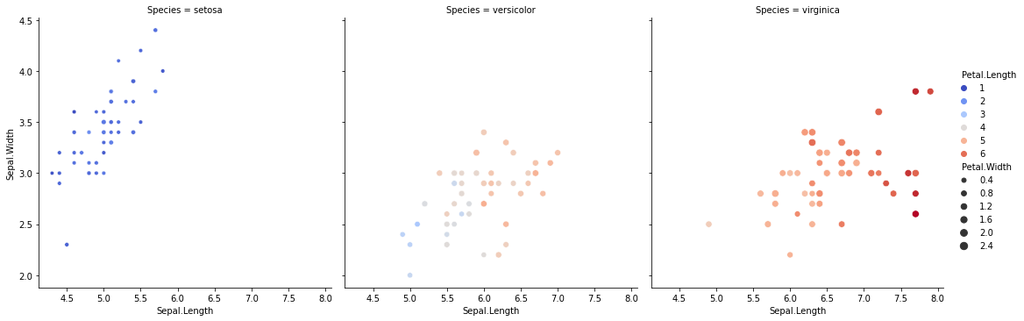

```python
sns.relplot(data = iris, x='Sepal.Length', y = 'Sepal.Width',
            hue = 'Petal.Length',
            col = 'Species',
            size = 'Petal.Width',
            palette=sns.color_palette('coolwarm', as_cmap=True),
            kind='scatter')

plt.show()
```

For example we make a "custom" diverging scale with the `sns.diverging_palette()` function.

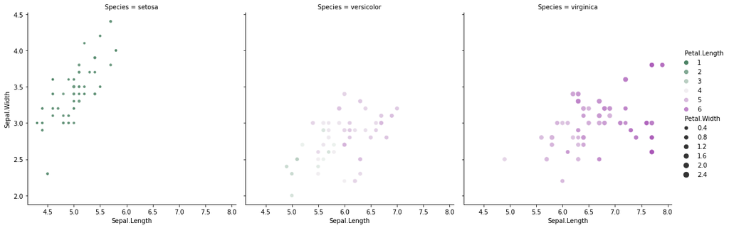

```python
sns.relplot(data = iris, x='Sepal.Length', y = 'Sepal.Width',
            hue = 'Petal.Length',
            col = 'Species',
            size = 'Petal.Width',
            palette=sns.diverging_palette(145, 300, s=60, as_cmap=True),
            kind='scatter')

plt.show()
```

A dark theme can be useful with this diverging scale.

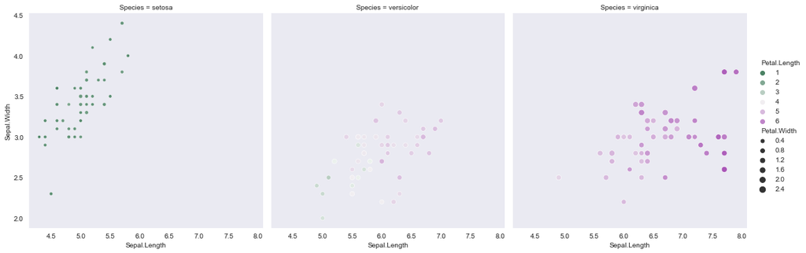

```python
sns.set_style('dark')

sns.relplot(data = iris, x='Sepal.Length', y = 'Sepal.Width',
            hue = 'Petal.Length',
            col = 'Species',
            size = 'Petal.Width',
            palette=sns.diverging_palette(145, 300, s=60, as_cmap=True),
            kind='scatter')

plt.show()
```

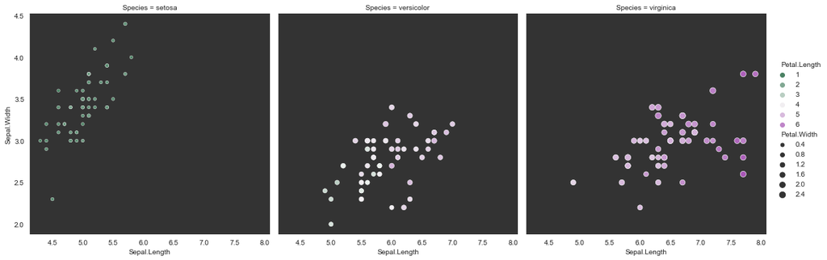

```python
sns.set_style('dark', {"axes.facecolor": "0.2"})

sns.relplot(data = iris, x='Sepal.Length', y = 'Sepal.Width',
            hue = 'Petal.Length',
            col = 'Species',
            size = 'Petal.Width',
            palette=sns.diverging_palette(145, 300, s=60, as_cmap=True),
            kind='scatter')

plt.show()
```

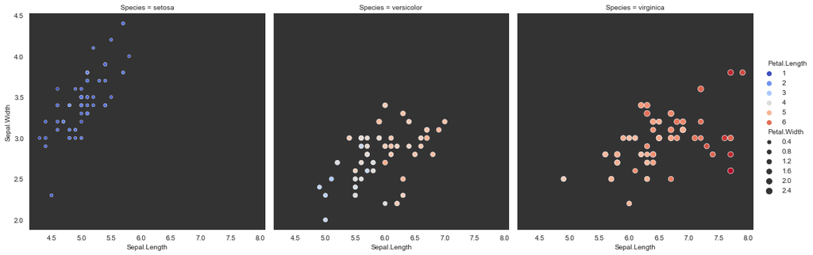

```python
sns.relplot(data = iris, x='Sepal.Length', y = 'Sepal.Width',
            hue = 'Petal.Length',
            col = 'Species',
            size = 'Petal.Width',
            palette='coolwarm',
            kind='scatter')

plt.show()
```

## Trend lines

Seaborn calls trends "regression models". There are two functions:

- figure level: `sns.lmplot()`
- axes level: `sns.regplot()`

We need to use `sns.lmplot()` to apply a trend "smoother" for each value of `Species`.

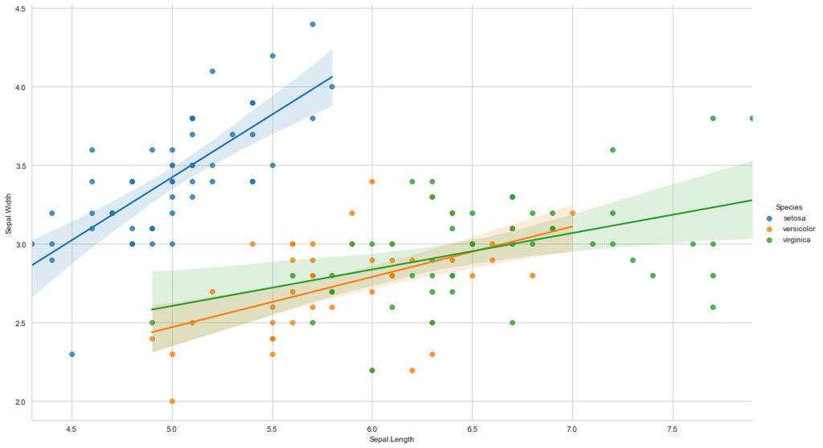

```python
sns.set_style('whitegrid')

sns.lmplot(data = iris, x='Sepal.Length', y='Sepal.Width',
           hue='Species',
           height = 8, aspect=1.7)

plt.show()
```

Specify the markers to have different shapes, we need to provide the shapes to use.

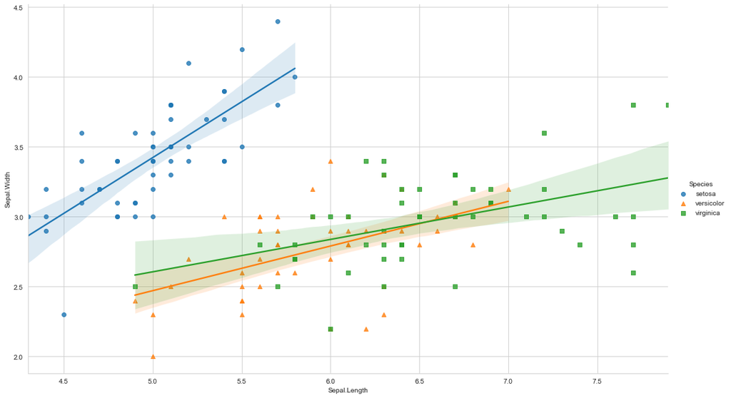

```python
sns.lmplot(data = iris, x='Sepal.Length', y='Sepal.Width',
           hue='Species',
           markers=['o', '^', 's'],
           height = 8, aspect=1.7)

plt.show()
```

We can increase the marker size via the `scatter_kws` argument.

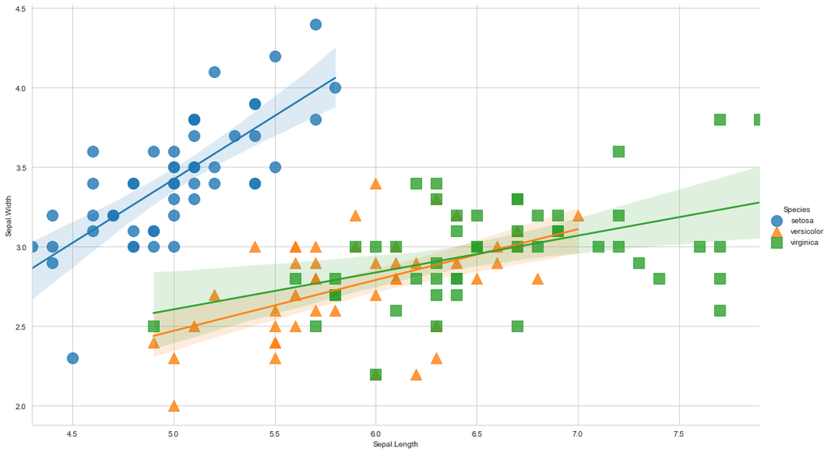

```python
sns.lmplot(data = iris, x='Sepal.Length', y='Sepal.Width',
           hue='Species',
           markers=['o', '^', 's'],
           scatter_kws={'s': 200},
           height = 8, aspect=1.7)

plt.show()
```

Can change the categorical color palette with the `palette` argument.

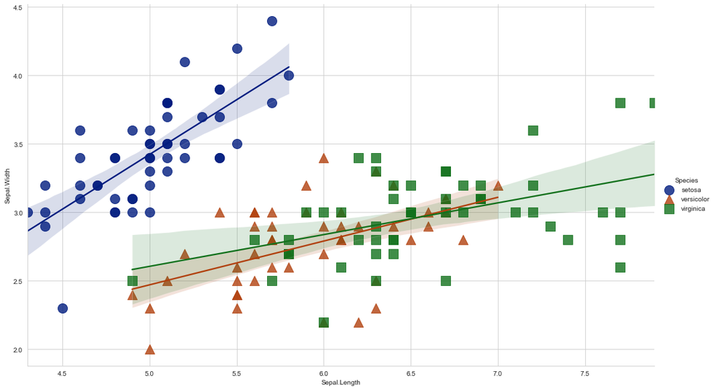

```python
sns.lmplot(data = iris, x='Sepal.Length', y='Sepal.Width',
           hue='Species',
           markers=['o', '^', 's'],
           scatter_kws={'s': 200},
           palette=sns.color_palette('dark', as_cmap=True),
           height = 8, aspect=1.7)

plt.show()
```

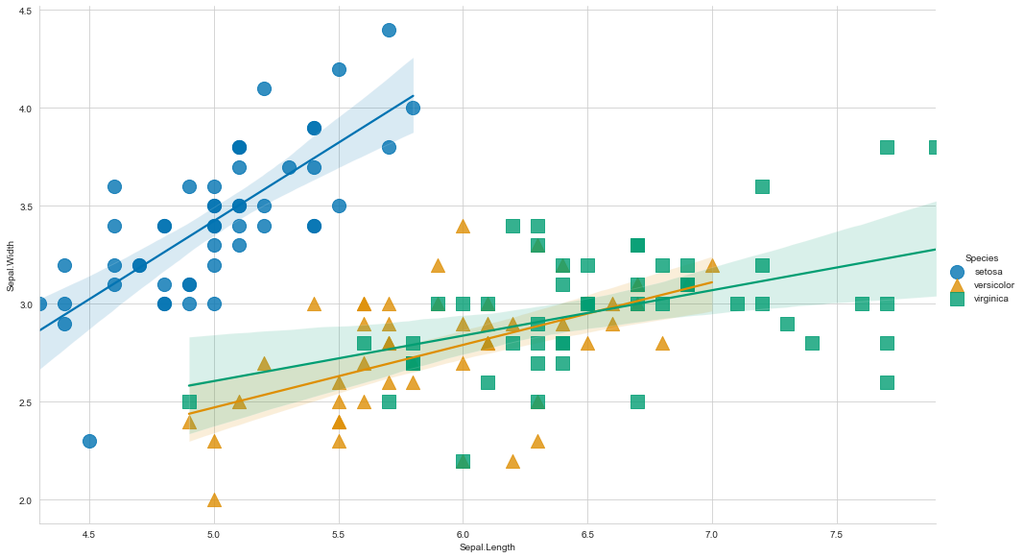

```python
sns.lmplot(data = iris, x='Sepal.Length', y='Sepal.Width',
           hue='Species',
           markers=['o', '^', 's'],
           scatter_kws={'s': 200},
           palette=sns.color_palette('colorblind', as_cmap=True),
           height = 8, aspect=1.7)

plt.show()
```

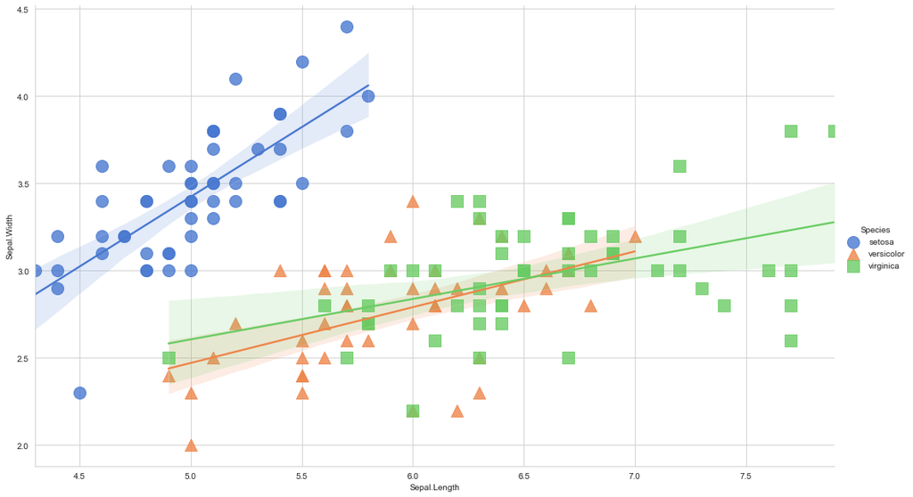

```python
sns.lmplot(data = iris, x='Sepal.Length', y='Sepal.Width',
           hue='Species',
           markers=['o', '^', 's'],
           scatter_kws={'s': 200},
           palette=sns.color_palette('muted', as_cmap=True),
           height = 8, aspect=1.7)

plt.show()
```

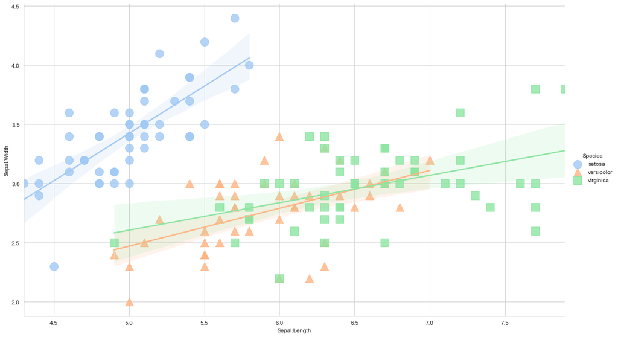

```python
sns.lmplot(data = iris, x='Sepal.Length', y='Sepal.Width',
           hue='Species',
           markers=['o', '^', 's'],
           scatter_kws={'s': 200},
           palette=sns.color_palette('pastel', as_cmap=True),
           height = 8, aspect=1.7)

plt.show()
```

Or we can provide manual colors.

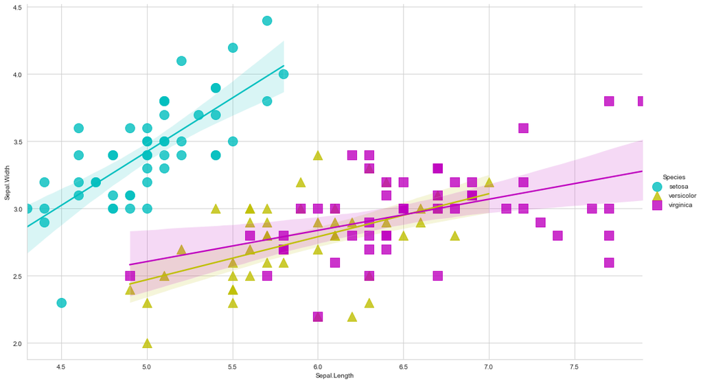

```python
sns.lmplot(data = iris, x='Sepal.Length', y='Sepal.Width',
           hue='Species',
           markers=['o', '^', 's'],
           scatter_kws={'s': 200},
           palette=['c', 'y', 'm'],
           height = 8, aspect=1.7)

plt.show()
```

Turn off scatter.

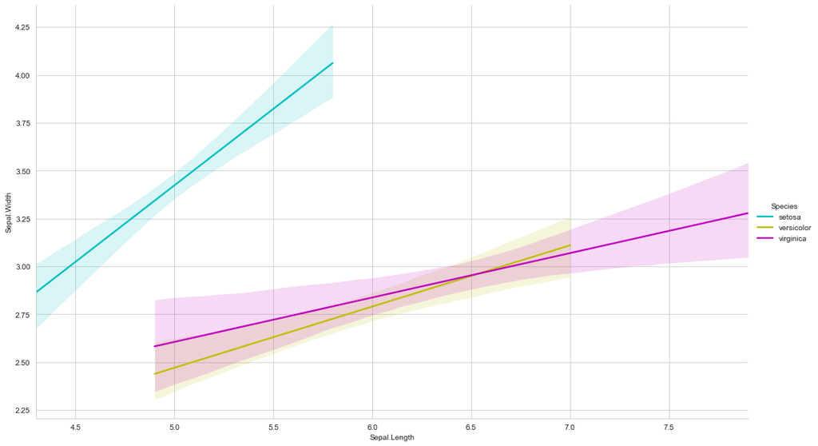

```python
sns.lmplot(data = iris, x='Sepal.Length', y='Sepal.Width',
           hue='Species',
           markers=['o', '^', 's'],
           scatter=False,
           scatter_kws={'s': 200},
           palette=['c', 'y', 'm'],
           height = 8, aspect=1.7)

plt.show()
```

Remove the confidence interval, `ci=None`.

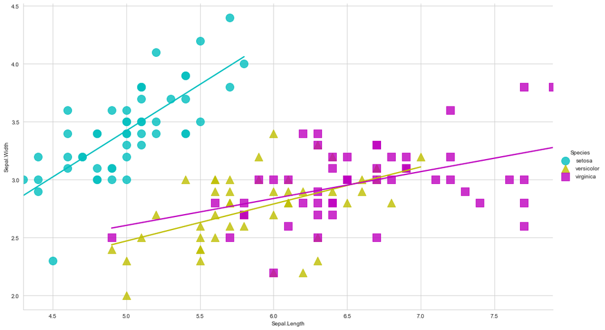

```python
sns.lmplot(data = iris, x='Sepal.Length', y='Sepal.Width',
           hue='Species',
           markers=['o', '^', 's'],
           ci=None,
           scatter_kws={'s': 200},
           palette=['c', 'y', 'm'],
           height = 8, aspect=1.7)

plt.show()
```

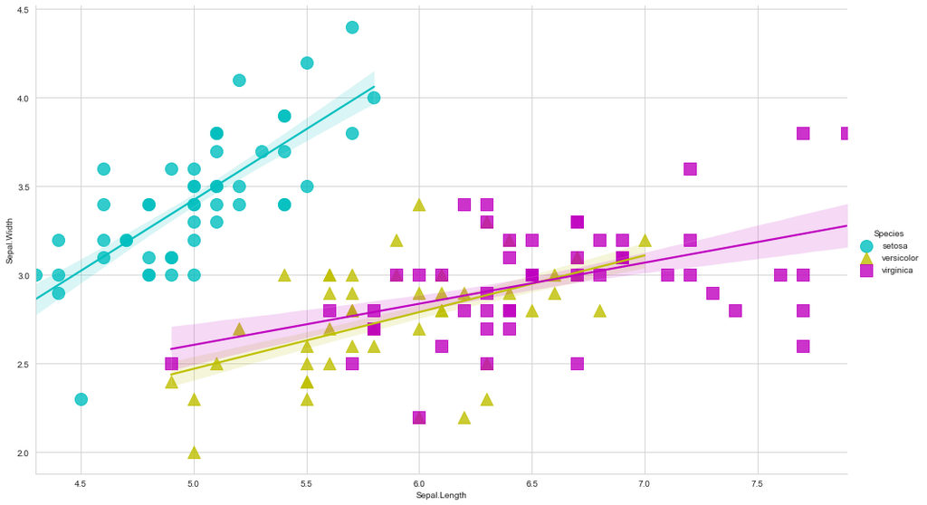

```python
sns.lmplot(data = iris, x='Sepal.Length', y='Sepal.Width',
           hue='Species',
           markers=['o', '^', 's'],
           ci=68,
           scatter_kws={'s': 200},
           palette=['c', 'y', 'm'],
           height = 8, aspect=1.7)

plt.show()
```

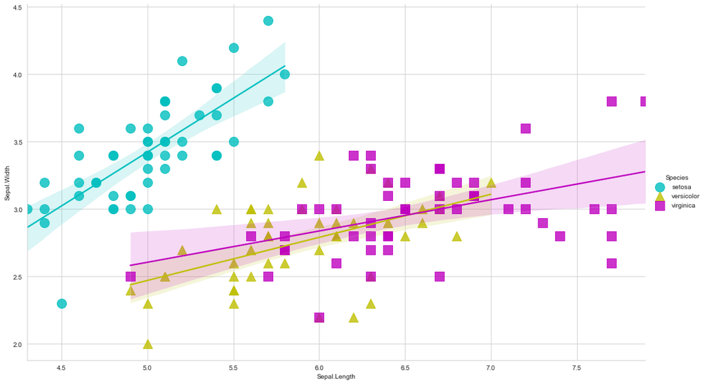

```python
sns.lmplot(data = iris, x='Sepal.Length', y='Sepal.Width',
           hue='Species',
           markers=['o', '^', 's'],
           ci=95,
           scatter_kws={'s': 200},
           palette=['c', 'y', 'm'],
           height = 8, aspect=1.7)

plt.show()
```

We need to combine the figure level and axes level functions from Seaborn to plot the regression line across all data and per group.

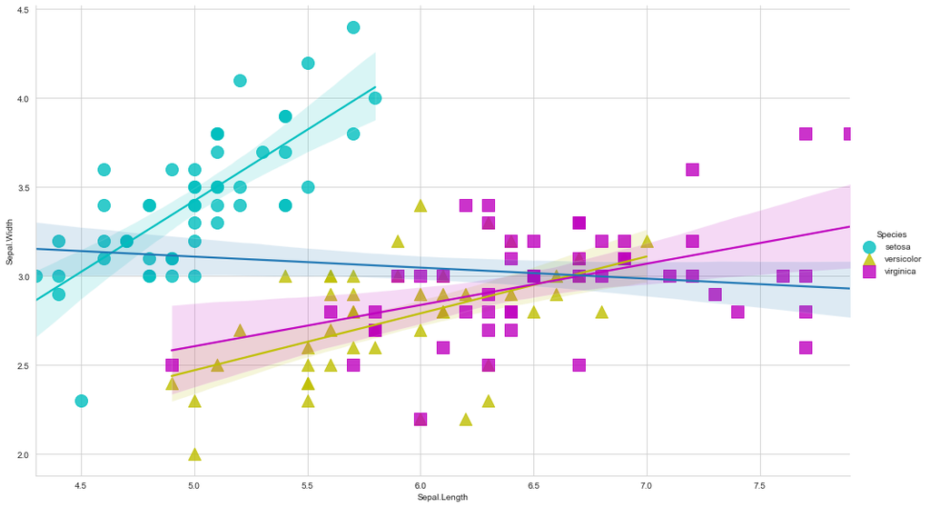

```python
g = sns.lmplot(data = iris, x='Sepal.Length', y='Sepal.Width',
           hue='Species',
           markers=['o', '^', 's'],
           ci=95,
           scatter_kws={'s': 200},
           palette=['c', 'y', 'm'],
           height = 8, aspect=1.7)

sns.regplot(ax = g.ax,
            data = iris, x='Sepal.Length', y='Sepal.Width',
            ci = 95,
            scatter=False)

plt.show()
```